# Covid Friday

20202-06-30

## Introducción

El objetivo de este post es mostrar una forma de cómo trabajar con diferentes tipos de integraciones (APIs) para descargar y analizar datos de internet. Puntualmente voy a trabajar con Google trends y con Twitter. Dicho lo anterior quiero analizar un efecto del `Covid` dado el día sin IVA en Colombia. El porque de esto obedece a una curiosidad puntual y es entender sociológicamente cómo fue interpretada esta política por el grueso de la población a la par de poder desarrollar algún tipo de inferencia. Me gustaría contar con él complemente de este post la interpretación u opinión de un economista (de bien) que admiro muchísimo [Carlos Ospino](https://www.linkedin.com/in/cospino/)[^1], para tener así una teoría más fuerte al respecto.

## Covid Friday

El Covid Friday es el nombre al día sin IVA dado por Bloomberg,y es gracias a la forma aparente de como se manejo el distanciamiento social por parte de las grandes superficies en el país[^2]

[figure not shown]

En este punto comparto la preocupación de varios medios internacionales dado que conoceremos los efectos directos de esta política a nivel de contagios hasta el nueve de Julio y con base a ello hay un problema menor sobre como separar los escenarios del aumento de los contagios gracias a esta implementación.

Por el momento lo que sí se puede hacer es evaluar cómo ha sido la evolución de este hecho a un nivel muy macro.

## Tendencia y diferencias

Lo primero a evaluar es el comportamiento de dos keywords (‘Covid Friday’ y ‘Día sin IVA’) por parte de google a nivel mundial, para así ir filtrando por grupos de interés. Para ello usaré la librería [gtrendsR](https://cran.r-project.org/web/packages/gtrendsR/gtrendsR.pdf)[^3], la cual me permitirá generar la conexión vía API con google trends.

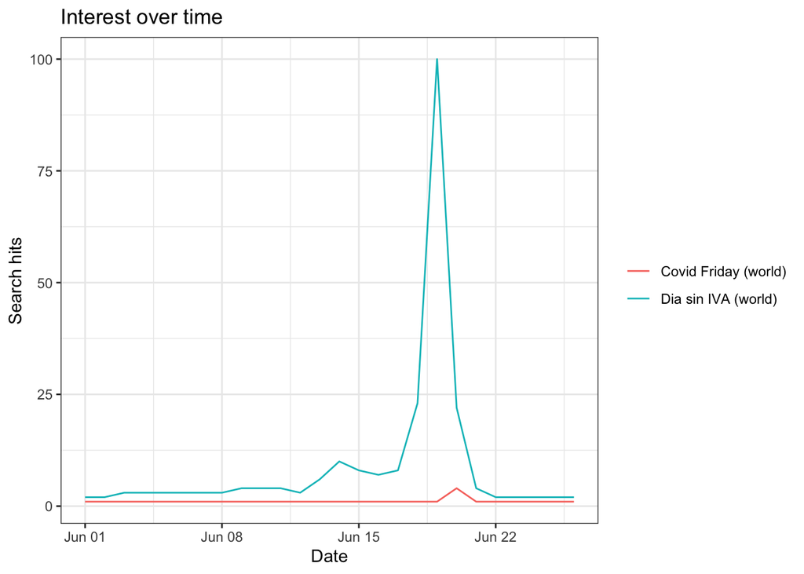

En términos generales parece que a nivel mundial la noticia no hizo tanto eco, pero la mención de Bloomberg debió tener impacto en alguna parte, por lo tanto voy a explorar a nivel geográfico donde fue más buscada.

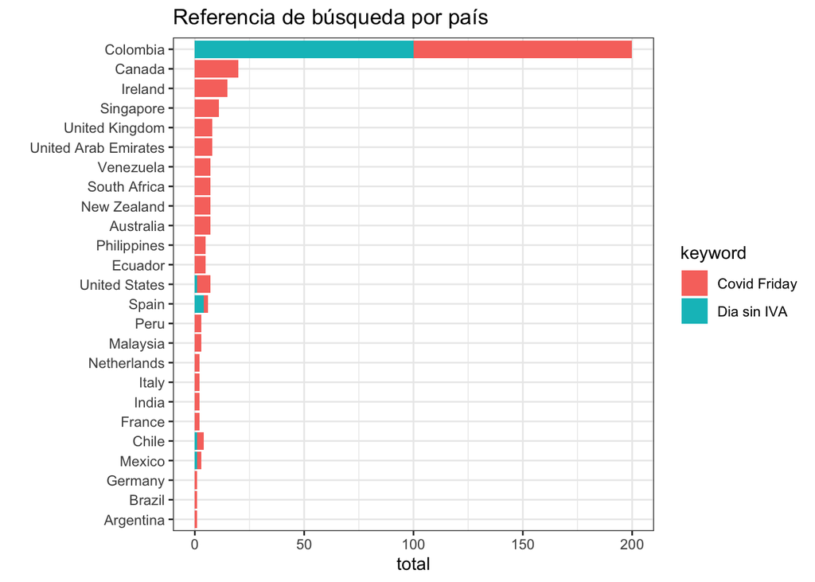

Lo interesante en esta parte es saber cómo generar el filtro por los países donde se buscan a la par las keywords. Solo para entender dichas búsquedas y así tener un mapa de búsqueda definido trabajaré con Colombia, Chile, México, y USA .

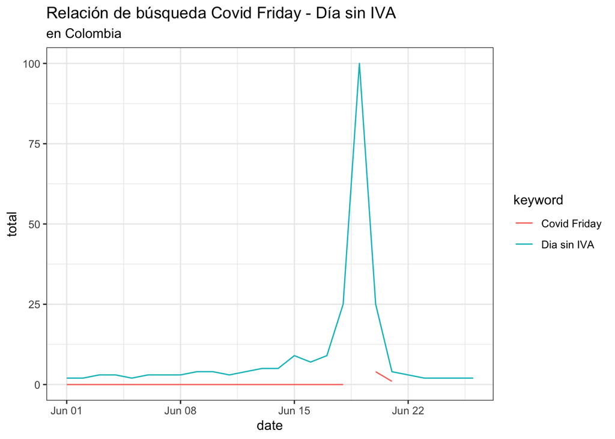

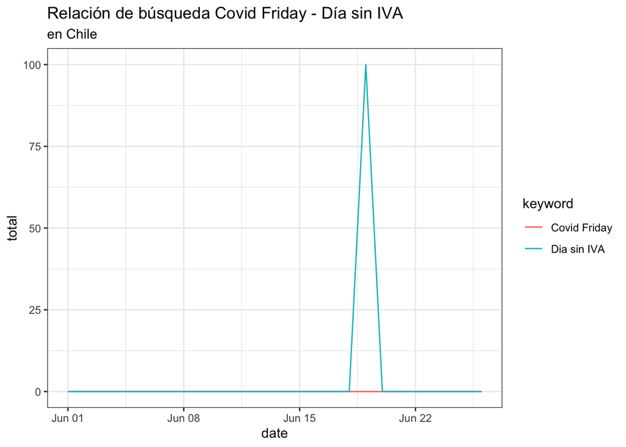

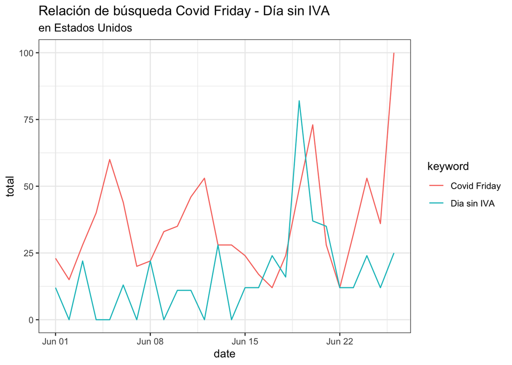

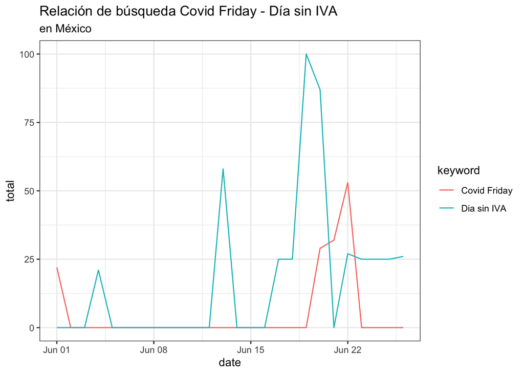

[^1]: Recomiendo su trabajo sobre economía laboral y los invito a seguirlo, pienso que el marcará la agenda de la próxima decada y será referente del nivel de Hayek o Krugman (opinión personal).
[^2]: Imagen tomada de : https://www.larepublica.co/economia/bloomberg-dice-que-colombia-hizo-black-friday-en-medio-de-la-cuarentena-3021028
[^3]: Para no tener latencia con esta API recomiendo usar la terminal de su computador en vez del interfraz gráfico.